# Cuestionario 2 · Regresión Lineal simple y múltiple

Bioestadística · Semana 2 · 2026-II

Autor/a

Fecha de publicación

4 de octubre de 2026

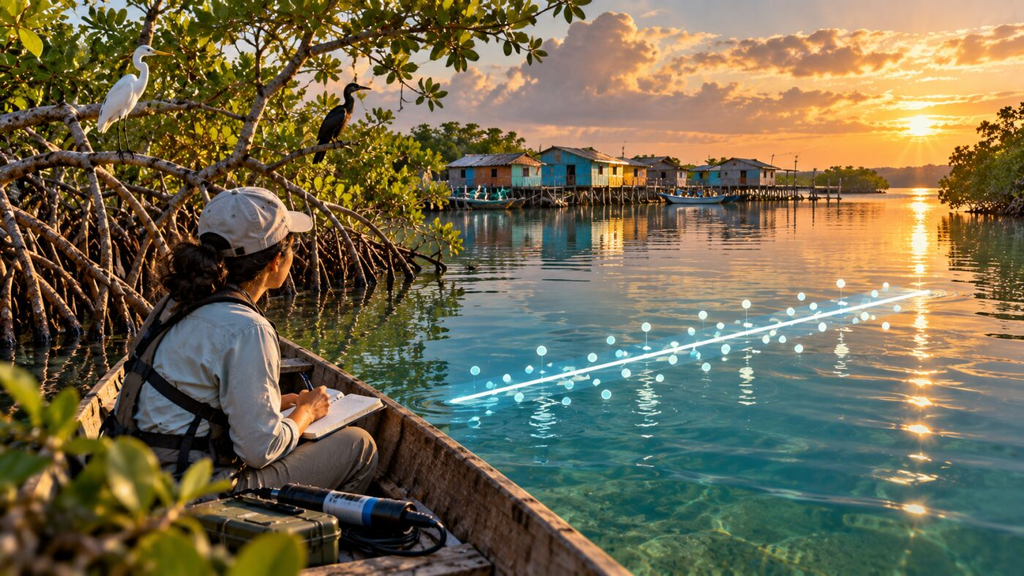

**NotaCómo usar este cuestionario**

Ejercicio aplicado (RA1, RA2) que se resuelve después del `Taller · Regresión Lineal Simple y Múltiple en R` y de la práctica de opción múltiple (Cuestionario 1), antes de la sesión de GLM. Cada bloque plantea una situación aplicada a una línea de investigación del grupo; no son los datos del taller, de modo que hay que razonar el resultado en lugar de recordarlo.

**ImportanteRuta mínima calificable (45 pts · rúbrica R1)**

| Bloque | Qué se entrega | Criterio de R1 |
| --- | --- | --- |
| **A — Conceptos** | **4 de las 8 preguntas** (A1 a A8), a elección | 1. Razonamiento y elección (20) · 2. Ejecución e interpretación (15) |
| **B, C o D — Casos aplicados** | **Uno de los tres bloques, completo** (B: jurel; C: biomasa bentónica; D: selección de modelos) | 1. Razonamiento y elección · 2. Ejecución e interpretación |
| **E — Proyecto de grado** | **E1 y E2** (obligatorias) | 3. Proyecto propio (10) |

- Al inicio de la entrega se indica qué preguntas del Bloque A y qué bloque (B, C o D) se eligieron. Si no se indica, se califican las cuatro primeras preguntas resueltas del Bloque A y el primer bloque resuelto entre B y D.
- Los ítems que no forman parte de la ruta elegida quedan como práctica: no suman ni restan.
- Se entrega en Moodle el `.qmd` con la ruta mínima resuelta y su render (HTML o PDF). Cierra el **jueves 22 de octubre, 23:59**. La tarea se habilita al completar la práctica de opción múltiple (Cuestionario 1).

Las respuestas no se incluyen en esta versión: se discuten en clase después del cierre de la entrega.

## Bloque A — Conceptos

**Tip**

**Ruta mínima:** responder **4 de las 8 preguntas** (A1 a A8), a elección.

**A1.** Un compañero mide temperatura y salinidad en 20 estaciones de la Ciénaga Grande de Santa Marta y encuentra una correlación de r = −0.71. Concluye: *“la temperatura reduce la salinidad”*. ¿Qué le falta a esa conclusión y qué tendría que hacer distinto para poder afirmarla?

**A2.** En una regresión simple, el IC 95 % de la pendiente es [−0.8, 3.2]. ¿Qué se concluye sobre la relación entre X e Y, y por qué el valor de r² por sí solo no basta para responder?

**A3.** ¿Por qué en la relación riqueza de especies–área de un parche (manglar, isla, arrecife) casi siempre conviene ajustar el modelo en escala log-log y no en la escala original? Responder en términos de la forma de la relación, no solo de “porque así sale mejor el r²”.

**A4.** Un modelo múltiple tiene VIF = 1.3 para todos sus predictores. ¿Qué indica eso, y qué tendría que observarse para preocuparse por la interpretación de los coeficientes?

**A5.** Dos modelos candidatos difieren en AIC por 1.1 puntos. ¿Se puede decir con confianza cuál es “el mejor modelo”? Justificar.

**A6.** Al graficar los residuos de `lm(Y ~ X)` contra los valores ajustados, una compañera observa un patrón en forma de embudo (la dispersión crece hacia la derecha). ¿Qué supuesto se está violando y qué dos caminos tiene para corregirlo?

**A7.** En un modelo con 25 observaciones y 2 parámetros, una observación tiene distancia de Cook = 1.8, mientras que el resto está por debajo de 0.3. ¿Qué significa, y qué NO debería hacerse automáticamente con ese dato?

**A8.** En un modelo log₁₀(riqueza) = 0.60 + 0.31 × log₁₀(área), un estudiante afirma: *“por cada hectárea adicional se ganan 0.31 especies”*. ¿Por qué es incorrecto? ¿Qué pasa con la riqueza esperada si el área del parche se duplica?

## Bloque B — Longitud del jurel según su edad

**Tip**

**Ruta mínima:** resolver **uno** de los Bloques B, C o D, completo.

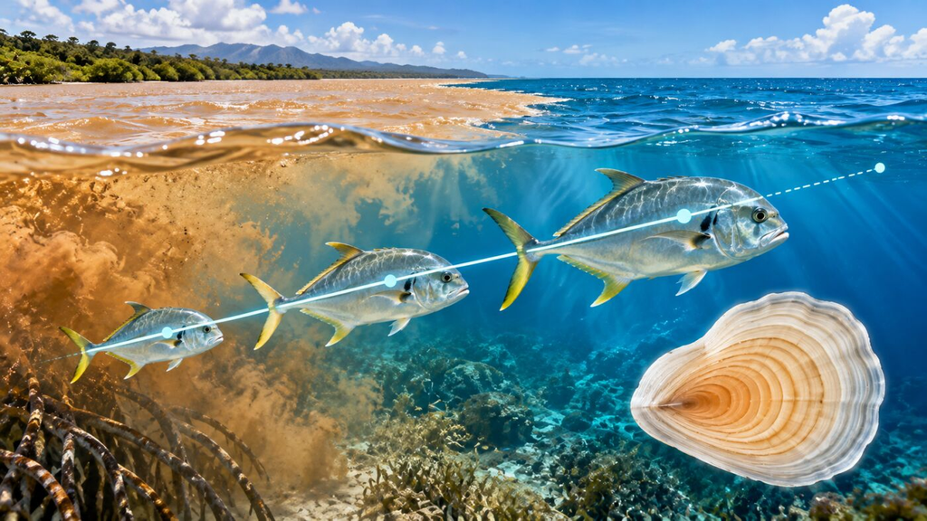

Un estudiante mide la longitud estándar (mm) y estima la edad (años, por anillos de otolito) de 25 individuos de jurel (*Caranx hippos*) capturados en la desembocadura del Magdalena. Ajusta una regresión lineal simple y obtiene:

| Coeficiente | Estimado | IC 95 % | Valor p |
| --- | --- | --- | --- |
| Intercepto | 145.1 | [128.0, 162.1] | < 0.001 |
| Edad (años) | 18.3 | [14.7, 22.0] | < 0.001 |

r² = 0.82, n = 25

**B1.** Escribir la ecuación del modelo y explicar en una frase qué representa cada coeficiente en este contexto biológico.

**B2.** ¿Qué longitud se esperaría, según el modelo, para un individuo de 4.5 años? Mostrar el cálculo.

**B3.** El intercepto (145.1 mm) representaría la longitud esperada a edad = 0. ¿Tiene sentido biológico interpretarlo literalmente? ¿Por qué?

**B4.** Si el estudiante solo hubiera muestreado individuos de 1 a 3 años y quisiera predecir la longitud de un individuo de 8 años con este mismo modelo, ¿qué problema estadístico estaría cometiendo?

## Bloque C — Biomasa bentónica, profundidad y distancia a la costa

**Tip**

**Ruta mínima:** resolver **uno** de los Bloques B, C o D, completo.

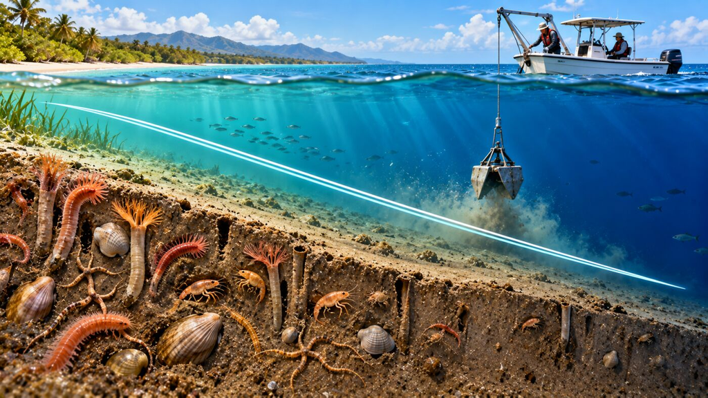

Para su proyecto sobre comunidades bentónicas de fondos blandos, una estudiante ajusta un modelo múltiple con 28 estaciones:

biomasa (g/m²) = 116.1 − 0.98 × profundidad − 0.03 × distancia_costa

| Predictor | Estimado | Error estándar | Valor p | VIF |
| --- | --- | --- | --- | --- |
| Profundidad (m) | −0.981 | 0.394 | 0.020 | 6.57 |
| Distancia a la costa (km) | −0.034 | 0.384 | 0.930 | 6.57 |

r² = 0.635, cor(profundidad, distancia_costa) = 0.92

**C1.** El coeficiente de “distancia a la costa” no es significativo (p = 0.93) y su error estándar es grande en relación con su estimado. Con lo visto sobre el VIF, ¿por qué ocurre esto? ¿Significa necesariamente que la distancia a la costa no tiene relación real con la biomasa?

**C2.** Mencionar dos formas distintas en que la estudiante podría resolver el problema antes de reportar el modelo.

**C3.** ¿Por qué no basta con mirar el r² (0.635, razonable) para decidir que este modelo múltiple está bien especificado?

## Bloque D — Selección de modelos: diversidad funcional de peces en la CGSM

**Tip**

**Ruta mínima:** resolver **uno** de los Bloques B, C o D, completo.

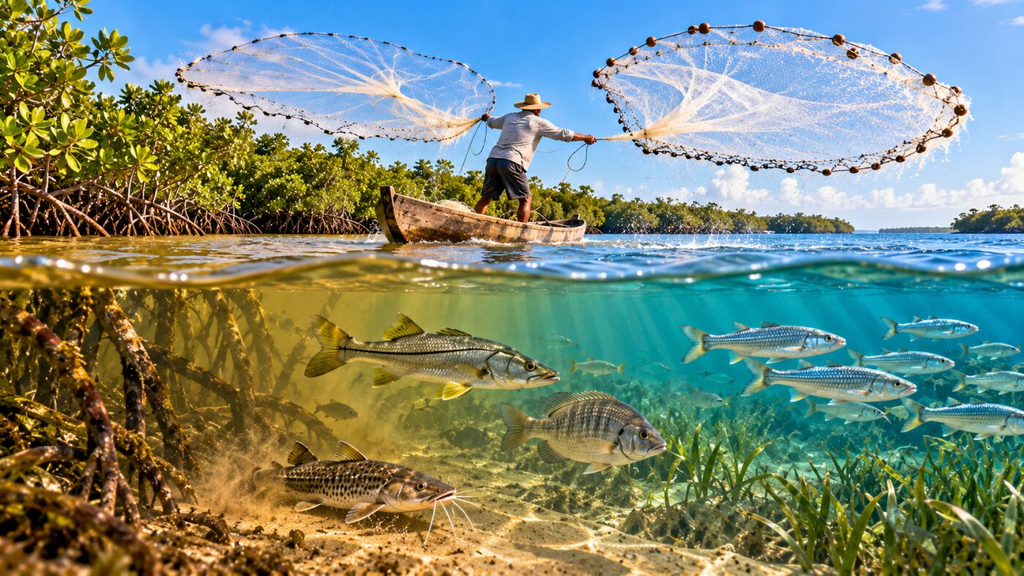

Un estudiante evalúa cómo la variabilidad ambiental modula la diversidad funcional (FD) del ensamblaje íctico en la Ciénaga Grande de Santa Marta, comparando 4 modelos candidatos con 24 estaciones:

| Modelo | k | r² | AIC | ΔAIC |
| --- | --- | --- | --- | --- |
| FD ~ salinidad + profundidad | 3 | 0.715 | −56.79 | 0.00 |
| FD ~ salinidad + profundidad + conectividad | 4 | 0.728 | −55.96 | 0.83 |
| FD ~ salinidad | 2 | 0.422 | −41.83 | 14.96 |
| FD ~ profundidad | 2 | 0.145 | −32.43 | 24.36 |

**D1.** Ordenar los cuatro modelos de mejor a peor según AIC. ¿Cuál se escogería como modelo final, y por qué no es simplemente “el de r² más alto”?

**D2.** El modelo con conectividad tiene un r² apenas mayor (0.728 frente a 0.715) y un ΔAIC de solo 0.83 respecto al mejor. Bajo la convención habitual (ΔAIC < 2 ≈ soporte similar), ¿qué convendría hacer: reportar el modelo más simple, el más complejo o ambos? Justificar considerando también la interpretabilidad ecológica.

**D3.** Los modelos con un solo predictor tienen ΔAIC muy altos (> 10). ¿Qué indica esto sobre modelar la diversidad funcional en función de una sola variable ambiental en este sistema?

## Bloque E — Proyecto de grado

**Tip**

**Ruta mínima:** **E1 y E2 son obligatorias**. Se califican con el criterio 3 de la rúbrica R1 (10 pts).

**E1.** En un par de frases, plantear una pregunta de regresión (simple o múltiple) relacionada con el propio proyecto. Identificar la variable respuesta, los predictores y si se esperaría necesitar una transformación.

**E2.** Si hubiera dos predictores candidatos que se sospecha están correlacionados (p. ej., dos variables ambientales que suelen variar juntas en el sistema), ¿qué se revisaría antes de interpretar sus coeficientes por separado? ¿Cómo podría el diseño de muestreo reducir el problema?

## Referencias

- Quinn, G. P., & Keough, M. J. (2024). *Experimental Design and Data Analysis for Biologists* (2nd ed.). Cambridge University Press.
- Logan, M. (2011). *Biostatistical Design and Analysis Using R*. Wiley-Blackwell.

**Nota**

Los escenarios de este cuestionario son de elaboración propia para este curso, inspirados en el estilo de preguntas aplicadas de la bibliografía base (interpretar salidas de modelos en un contexto biológico), pero con datos, contextos y enunciados propios; no reproducen los ejercicios ni las cifras de las fuentes citadas.